# Sign_Language_Detection

## **Tensorflow in Computer Vision**

TensorFlow is a widely-used open-source deep learning framework that is highly effective in computer vision applications. It provides a robust set of tools and libraries to build, train, and deploy computer vision models for tasks such as image classification, object detection, image segmentation, and style transfer.

Key features of TensorFlow in computer vision:

1. **Pretrained Models:** TensorFlow offers pretrained models like Inception, ResNet, and MobileNet, which can be used for transfer learning to solve specific vision problems with less training data.
2. **TensorFlow Hub:** A repository of reusable models for vision tasks, such as face detection, object recognition, and pose estimation, allowing developers to build sophisticated applications quickly.
3. **TensorFlow Lite:** An optimized version of TensorFlow for deploying models on mobile and edge devices, making it ideal for real-time computer vision tasks like augmented reality and on-device object detection.
4. **Keras API:** With TensorFlow's high-level Keras API, users can easily build convolutional neural networks (CNNs), which are essential for processing images and video data.
5. **TensorFlow Object Detection API:** A specialized tool for object detection tasks that provides access to ready-to-use models, customizable pipelines, and training utilities.

TensorFlow's flexibility and extensive ecosystem make it ideal for advancing computer vision in various domains such as medical imaging, autonomous vehicles, and robotics.

[figure not shown]

### **Import Libraries**

```python
import numpy as np
from matplotlib import pyplot as plt
import cv2
import os
import sys
from sklearn.model_selection import train_test_split
from sklearn.metrics import accuracy_score, multilabel_confusion_matrix
from tensorflow.keras.utils import to_categorical
from tensorflow.keras.models import Sequential
from tensorflow.keras.layers import LSTM, Dense
from tensorflow.keras.callbacks import TensorBoard
import mediapipe as mp
```

### **Mediapipe**

*Mediapipe is an open-source framework developed by Google for building cross-platform, real-time machine learning applications. It offers pre-built pipelines and customizable components for tasks like hand tracking, face detection, pose estimation, and object detection. Mediapipe is optimized for performance, working efficiently on both mobile devices and desktop platforms.*

*One of its key features is the ability to process video streams in real-time, making it ideal for applications like augmented reality, gesture recognition, and live camera-based interactions. Mediapipe provides easy-to-use APIs in Python and C++ and supports platforms like Android, iOS, and Web.*

*Its modular design enables developers to integrate machine learning models seamlessly with MediaPipe's high-performance processing of media data.*

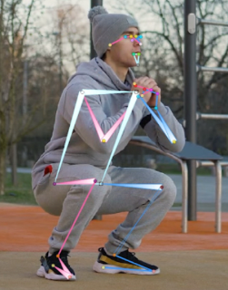

```python
#holistic model
mp_holistic = mp.solutions.holistic

#drawing utilities
mp_drawing = mp.solutions.drawing_utils

#face mesh model
mp_face_mesh = mp.solutions.face_mesh
```

```python
def mediapipe_detection(image,model):
     #color conversion from BGR to RGB
    image = cv2.cvtColor(image,cv2.COLOR_BGR2RGB)
    image.flags.writeable = False

     #make prediction
    results = model.process(image)

     #change the image to writeable
    image.flags.writeable = True

     #color conversion from RGB to BGR
    image = cv2.cvtColor(image,cv2.COLOR_RGB2BGR)
    return image, results
```

### **cv2**

*OpenCV (Open Source Computer Vision Library), commonly referred to as CV2 in Python, is a powerful open-source library used for computer vision and image processing tasks. Developed in C++, it provides a vast set of tools to analyze and process images and videos in real-time.*

**CV2 can handle a wide range of tasks such as:**

- Image manipulation (blurring, sharpening, resizing)
- Feature detection (edges, corners, contours)
- Object detection and recognition
- Video analysis (motion detection, tracking)
- Image transformation (rotation, translation, perspective changes)

*It also supports machine learning techniques and can integrate with deep learning frameworks like TensorFlow and PyTorch. Due to its versatility, OpenCV is widely used in fields such as robotics, augmented reality, and automated surveillance.*

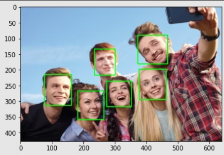

# **Connections**

### **1. mp.holistic.FACE_CONNECTIONS:**

`mp.holistic.FACE_CONNECTIONS` is a predefined constant in the Mediapipe Holistic module that represents the connections between various facial landmarks. These connections are used to define the structure of the face in tasks like face detection, facial mesh, and keypoint tracking.

When using Mediapipe's face mesh models, `FACE_CONNECTIONS` allows the visualization of the relationships between facial landmarks, such as connecting the eyes, mouth, nose, and other key facial features. This is particularly useful for tasks like facial expression recognition, augmented reality, or creating 3D face models.

For example, when processing a video feed or image, `mp.holistic.FACE_CONNECTIONS` will show lines connecting key facial points, providing a more structured understanding of the face's geometry in real-time.

### **2. mp.holistic.POSE_CONNECTIONS:**

`mp.holistic.POSE_CONNECTIONS` is a predefined constant in Mediapipe's Holistic module that represents the connections between various pose landmarks on the human body. These connections define the skeletal structure used in pose estimation tasks. By joining specific key points such as shoulders, elbows, knees, and ankles, Mediapipe forms a skeleton-like representation of the human body.

This is particularly useful in applications like fitness tracking, sports analysis, gesture recognition, and augmented reality. When using Mediapipe's pose detection, `POSE_CONNECTIONS` helps to visualize the human pose in real-time, providing insight into body movements and positions.

### **3.mp.holistic.HAND_CONNECTIONS:**

`mp.holistic.HAND_CONNECTIONS` is a constant in Mediapipe's Holistic module that defines the connections between different hand landmarks. These connections create a skeletal structure of the hand, joining key points like the fingertips, knuckles, and palm base, which are critical for understanding hand gestures and finger movements.

This is especially useful in applications like gesture recognition, sign language interpretation, virtual reality interactions, and controlling devices through hand motions. By visualizing these connections, `mp.holistic.HAND_CONNECTIONS` helps developers track hand poses and movements in real-time, enabling interactive and intuitive user experiences.

### **Simple Landmarks**

```python
def draw_landmarks(image, results):
     #draw face connections
    mp_drawing.draw_landmarks(image, results.face_landmarks, mp_face_mesh.FACEMESH_TESSELATION)

     #draw pose connections
    mp_drawing.draw_landmarks(image, results.pose_landmarks, mp_holistic.POSE_CONNECTIONS)

     #draw left hand connections
    mp_drawing.draw_landmarks(image, results.left_hand_landmarks, mp_holistic.HAND_CONNECTIONS)

     #draw right hand connections
    mp_drawing.draw_landmarks(image, results.right_hand_landmarks, mp_holistic.HAND_CONNECTIONS)
```

### **Colored Landmarks**

```python
# colored landmarks
def draw_styled_landmarks(image, results):
    overlay = image.copy()
    mp_drawing.draw_landmarks(image, results.face_landmarks, mp_face_mesh.FACEMESH_TESSELATION,
                              mp_drawing.DrawingSpec(color = (80,110,10), thickness=1, circle_radius=1), #color landmark
                              mp_drawing.DrawingSpec(color=(80,256,121), thickness=1,circle_radius=1) #color connections
                              ) #draw face connections
    alpha = 0.6  # Adjust this value to control transparency (0.0 is fully transparent, 1.0 is fully opaque)
    cv2.addWeighted(overlay, alpha, image, 1 - alpha, 0, image)

    mp_drawing.draw_landmarks(image, results.pose_landmarks, mp_holistic.POSE_CONNECTIONS,
                              mp_drawing.DrawingSpec(color=(80,22,10),thickness=2, circle_radius=4),
                              mp_drawing.DrawingSpec(color=(80,44,121),thickness=2, circle_radius=2)
                              ) #draw pose connections

    mp_drawing.draw_landmarks(image, results.left_hand_landmarks, mp_holistic.HAND_CONNECTIONS,
                              mp_drawing.DrawingSpec(color=(121,22,76), thickness=2, circle_radius=4),
                              mp_drawing.DrawingSpec(color=(121,44,250), thickness=2, circle_radius=2)
                              ) #draw left hand connections

    mp_drawing.draw_landmarks(image, results.right_hand_landmarks, mp_holistic.HAND_CONNECTIONS,
                              mp_drawing.DrawingSpec(color=(245,117,66), thickness=2, circle_radius=4),
                                mp_drawing.DrawingSpec(color=(245,66,230), thickness=2, circle_radius=2)
                                ) #draw right hand connections
```

### **Check Landmarks using Opencv-python**

```python
cap = cv2.VideoCapture(1)
# Initiate or access holistic model
with mp_holistic.Holistic(min_detection_confidence=0.5, min_tracking_confidence=0.5) as holistic:
    while cap.isOpened():
        # read feed
        ret, frame = cap.read()
        # Make detections
        image, results = mediapipe_detection(frame, holistic)
        print(results)

        # Draw landmarks
        draw_styled_landmarks(image, results)

        # show to screen
        cv2.imshow('OpenCV Feed', image)

        # Break gracefully
        if cv2.waitKey(10) & 0xFF == ord('q'):
            break

    cap.release()
    cv2.destroyAllWindows()
```

```
<class 'mediapipe.python.solution_base.SolutionOutputs'>
```

[output not shown]

[output cut: 131 more lines]

[output not shown]

```python
# frame shape
frame.shape
```

```
(480, 640, 3)
```

### **with draw landmark function**

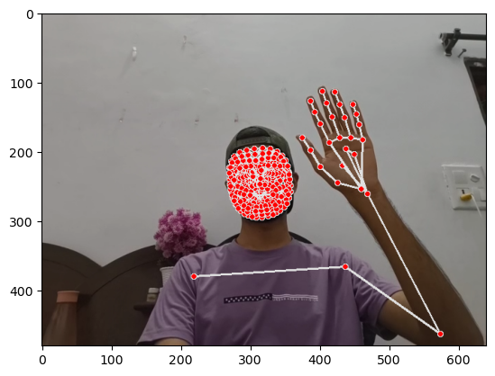

```python
# with landmarks
draw_landmarks(frame, results)
plt.imshow(cv2.cvtColor(frame, cv2.COLOR_BGR2RGB))
```

### **with draw_styled_landmark function**

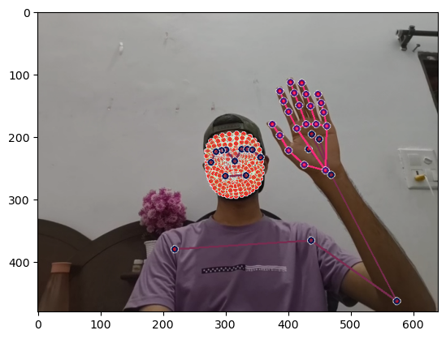

```python
# using draw_styled_landmarks function
draw_styled_landmarks(frame, results)
plt.imshow(cv2.cvtColor(frame, cv2.COLOR_BGR2RGB))
```

### **Extract KeyPoint Values**

**Landmark Values:** The face and hand landmark models will return no values if nothing detected. The pose model will return landmarks but the visibility value inside of each landmark will be low.

```python
# Keypoints values of pose landmarks
results.pose_landmarks
```

```
landmark {
  x: 0.376265705
  y: 0.4470281
  z: -0.607134163
  visibility: 0.999941945
}
landmark {
  x: 0.396463484
  y: 0.385944098
  z: -0.591947436
  visibility: 0.99986
}
landmark {
  x: 0.413203239
  y: 0.382551759
  z: -0.591760755
  visibility: 0.999868
}
landmark {
  x: 0.431194961
  y: 0.379342377
  z: -0.592117906
  visibility: 0.999869287
}
landmark {
  x: 0.356435448
  y: 0.397450268
  z: -0.557228565
  visibility: 0.999849141
}
landmark {
  x: 0.341578782
  y: 0.402361959
  z: -0.55631125
  visibility: 0.999848
}
landmark {
  x: 0.328044564
  y: 0.407365113
  z: -0.556522965
```

[output cut: 143 more lines]

```
  z: 0.640848517
  visibility: 4.19255557e-005
}
landmark {
  x: 0.602781475
  y: 2.70285678
  z: 0.206298396
  visibility: 0.000128189407
}
landmark {
  x: 0.430657208
  y: 2.72476482
  z: 0.150594682
  visibility: 8.51485092e-005
}
```

```python
# Extracted first pose landmark -> x, y, z, visibility
results.pose_landmarks.landmark[0]
```

```
x: 0.376265705
y: 0.4470281
z: -0.607134163
visibility: 0.999941945
```

```python
# Extract X value of pose landmark
results.pose_landmarks.landmark[0].x
```

```
0.3762657046318054
```

```python
#  x, y, z and visibility value in array
pose = []
for res in results.pose_landmarks.landmark:
    test = np.array([res.x, res.y, res.z, res.visibility])
    pose.append(test)
```

```python
pose
```

[output not shown]

**Getting error because landmark model detected nothing and generating error. So, We have to fill zero value if our landmark model detect nothing.**

```python
# Run this code to see error
# len(results.right_hand_landmarks.landmarks)
```

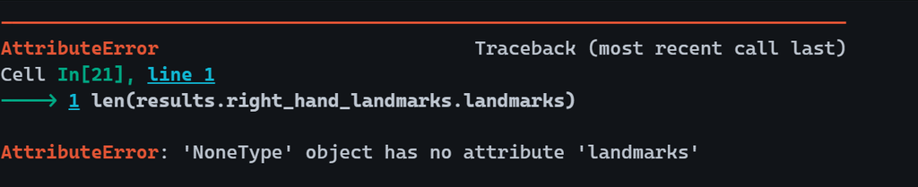

```python
def extract_keypoints(results):
    pose = np.array([[res.x, res.y, res.z, res.visibility] for res in results.pose_landmarks.landmark]).flatten() if results.pose_landmarks else np.zeros(33*4)
    face = np.array([[res.x, res.y, res.z] for res in results.face_landmarks.landmark]).flatten() if results.face_landmarks else np.zeros(468*3)
    lh = np.array([[res.x, res.y, res.z] for res in results.left_hand_landmarks.landmark]).flatten() if results.left_hand_landmarks else np.zeros(21*3)
    rh = np.array([[res.x, res.y, res.z] for res in results.right_hand_landmarks.landmark]).flatten() if results.right_hand_landmarks else np.zeros(21*3)
    return np.concatenate([pose, face, lh, rh])
```

```python
result_test = extract_keypoints(results)
result_test
```

### **Save Numpy file**

```python
np.save('0', result_test)
```

### **Load Numpy file**

```python
np.load('0.npy')
```

```
array([ 0.3762657 ,  0.4470281 , -0.60713416, ...,  0.        ,
        0.        ,  0.        ])
```

### **Setup Folders for Collection**

**Action Detection:** A key difference between action detection and other computer vision task is that a sequence of data rather than a single frame is used for detection.

### **6 Gestures -> hello, thanks, iloveyou, please, yes, no**

You can also create more gestures

```python
# Path for exported data, numpy arrays
DATA_PATH = os.path.join('MP_Data')

# Actions that we try to detect
actions = np.array(['hello', 'thanks', 'iloveyou', 'please', 'yes', 'no'])

# Thirty videos worth of data
no_sequences = 30

# Videos are going to be 30 frames in length
sequence_length = 30
```

```python
for action in actions:
    for sequence in range(no_sequences):
        try:
            os.makedirs(os.path.join(DATA_PATH, action, str(sequence)))
        except:
            pass
```

## **Collect Keypoint Values of Training and Testing**

### **Collection Breaks:**

Having breaks between each sequence collection allows you to reset and reposition yourself to collect the action from start to finish.

### **Shorten Breaks:**

In order to shorten the break between sequences collected change the value in cv2. waitTime() to a lower value. To increase the time increase the value.

```python
cap = cv2.VideoCapture(1)
# Initiate or access holistic model
with mp_holistic.Holistic(min_detection_confidence=0.5, min_tracking_confidence=0.5) as holistic:
    # while cap.isOpened():

    # new
    # loop through actions
    for action in actions:
        # loop through sequences aka videos
        for sequence in range(no_sequences):
            # Loop through video length aka sequence length
            for frame_num in range(sequence_length):

                # read feed
                ret, frame = cap.read()
                # Make detections
                image, results = mediapipe_detection(frame, holistic)
                print(results)

                # Draw landmarks
                draw_styled_landmarks(image, results)

                # new
                # Apply collection logic
                if frame_num == 0:
                    cv2.putText(image, 'STARTING COLLECTION', (120,200),
                                cv2.FONT_HERSHEY_SIMPLEX, 1, (0,255, 0), 4, cv2.LINE_AA)
                    cv2.putText(image, 'Collecting frames for {} Video Number {}'.format(action, sequence), (15,12),
                                cv2.FONT_HERSHEY_SIMPLEX, 0.5, (0, 0, 255), 1, cv2.LINE_AA)
                    # cv2.imshow('OpenCV Feed', image)
                    cv2.waitKey(2000)
                else:
                    cv2.putText(image, 'Collecting frames for {} Video Number {}'.format(action, sequence), (15,12),
                                cv2.FONT_HERSHEY_SIMPLEX, 0.5, (0, 0, 255), 1, cv2.LINE_AA)
                    # cv2.imshow('OpenCV Feed', image)

                keypoints = extract_keypoints(results)
                npy_path = os.path.join(DATA_PATH, action, str(sequence), str(frame_num))
                np.save(npy_path, keypoints)

                # show to screen
                cv2.imshow('OpenCV Feed', image)




                # show to screen
                cv2.imshow('OpenCV Feed', image)

        # Break gracefully
                if cv2.waitKey(10) & 0xFF == ord('q'):
                    break

    cap.release()
    cv2.destroyAllWindows()
```

```
<class 'mediapipe.python.solution_base.SolutionOutputs'>
```

[output not shown]

[output cut: 5344 more lines]

[output not shown]

### **Preprocess Data and Create Labels and Features**

```python
from sklearn.model_selection import train_test_split
from tensorflow.keras.utils import to_categorical
```

```python
label_map = {label:num for num, label in enumerate(actions)}
```

```python
label_map
```

```
{'hello': 0, 'thanks': 1, 'iloveyou': 2, 'please': 3, 'yes': 4, 'no': 5}
```

```python
sequences, labels = [], []
for action in actions:
    for sequence in range(no_sequences):
        window = []
        for frame_num in range(sequence_length):
            res = np.load(os.path.join(DATA_PATH, action, str(sequence), "{}.npy".format(frame_num)))
            window.append(res)
        sequences.append(window)
        labels.append(label_map[action])
```

```python
np.array(sequences).shape
```

```
(180, 30, 1662)
```

```python
np.array(sequences).shape
```

```
(180, 30, 1662)
```

```python
np.array(labels).shape
```

[output not shown]

```python
X = np.array(sequences)
y = to_categorical(labels).astype(int)
```

```python
y
```

```
array([[1, 0, 0, 0, 0, 0],
       [1, 0, 0, 0, 0, 0],
       [1, 0, 0, 0, 0, 0],
       ...,
       [0, 0, 0, 0, 0, 1],
       [0, 0, 0, 0, 0, 1],
       [0, 0, 0, 0, 0, 1]])
```

```python
X_train, X_test, y_train, y_test = train_test_split(X, y,random_state=41, test_size=0.05)
```

```python
X_train.shape, X_test.shape, y_train.shape, y_test.shape
```

```
((171, 30, 1662), (9, 30, 1662), (171, 6), (9, 6))
```

# **Build LSTM Neural Network**

### **LSTM Neural Network:**

A Long Short-Term Memory (LSTM) neural network is a type of recurrent neural network (RNN) designed to handle sequential data and overcome the limitations of traditional RNNs, particularly the problem of vanishing or exploding gradients during long sequences. LSTMs are widely used for tasks involving time series data, such as natural language processing (NLP), speech recognition, and stock price prediction.

Key components of LSTMs include:

- **Memory Cell:** Stores information over time, which helps in retaining important features from earlier time steps.
- **Input Gate:** Controls how much of the input is added to the memory cell.
- **Forget Gate:** Decides what information should be discarded from the cell.
- **Output Gate:** Controls the output based on the memory cell's current state.

These gates enable LSTMs to "remember" important data across long sequences, making them more effective for tasks like language modeling, machine translation, and anomaly detection, where context from earlier inputs is crucial for accurate predictions.

### **TensorBoard:**

TensorBoard is a visualization tool provided by TensorFlow that helps in monitoring and optimizing machine learning models. It allows users to visualize metrics like loss, accuracy, and other performance indicators over time during model training. TensorBoard is useful for diagnosing model behavior, understanding how the training process evolves, and comparing different models or hyperparameters.

Key features include:

- **Scalars:** Plot metrics such as loss and accuracy.
- **Graphs:** Visualize the computational graph of your model.
- **Histograms:** Analyze distributions of weights and biases over time.
- **Images:** Visualize image inputs or outputs during training.
- **Projector:** Embeddings like word vectors can be visualized in 2D or 3D.

Though primarily built for TensorFlow, TensorBoard can also be used with PyTorch and other deep learning frameworks to track training progress. It provides an interactive dashboard for better insight into how a model is learning, enabling developers to fine-tune models effectively.

```python
log_dir = os.path.join('Logs')
tb_callback = TensorBoard(log_dir=log_dir)
```

### **Neural Network Architecture**

```python
model = Sequential()
model.add(LSTM(64, return_sequences=True, activation='relu', input_shape=(30,1662)))
model.add(LSTM(128, return_sequences=True, activation='relu'))
model.add(LSTM(64, return_sequences=False, activation='relu'))
model.add(Dense(64, activation='relu'))
model.add(Dense(32, activation='relu'))
model.add(Dense(actions.shape[0], activation='softmax'))
```

### **Model Compiler**

```python
model.compile(optimizer='Adam', loss='categorical_crossentropy', metrics=['categorical_accuracy'])
```

### **Model Fit**

```python
model.fit(X_train, y_train, epochs=146, callbacks=[tb_callback])
```

```
6/6 ━━━━━━━━━━━━━━━━━━━━ 1s 98ms/step - categorical_accuracy: 0.9197 - loss: 0.1561
6/6 ━━━━━━━━━━━━━━━━━━━━ 1s 91ms/step - categorical_accuracy: 0.8856 - loss: 0.3181
6/6 ━━━━━━━━━━━━━━━━━━━━ 0s 67ms/step - categorical_accuracy: 0.9248 - loss: 0.2534
6/6 ━━━━━━━━━━━━━━━━━━━━ 1s 77ms/step - categorical_accuracy: 0.9187 - loss: 0.2003
6/6 ━━━━━━━━━━━━━━━━━━━━ 0s 65ms/step - categorical_accuracy: 0.9704 - loss: 0.1562
6/6 ━━━━━━━━━━━━━━━━━━━━ 0s 70ms/step - categorical_accuracy: 0.9688 - loss: 0.1051
6/6 ━━━━━━━━━━━━━━━━━━━━ 0s 71ms/step - categorical_accuracy: 0.9747 - loss: 0.0980
6/6 ━━━━━━━━━━━━━━━━━━━━ 0s 71ms/step - categorical_accuracy: 0.9838 - loss: 0.0824
6/6 ━━━━━━━━━━━━━━━━━━━━ 0s 67ms/step - categorical_accuracy: 0.9756 - loss: 0.1128
6/6 ━━━━━━━━━━━━━━━━━━━━ 0s 65ms/step - categorical_accuracy: 0.9773 - loss: 0.0682
6/6 ━━━━━━━━━━━━━━━━━━━━ 0s 67ms/step - categorical_accuracy: 0.9720 - loss: 0.0922
6/6 ━━━━━━━━━━━━━━━━━━━━ 0s 64ms/step - categorical_accuracy: 0.9652 - loss: 0.1168
6/6 ━━━━━━━━━━━━━━━━━━━━ 0s 74ms/step - categorical_accuracy: 0.9742 - loss: 0.0711
6/6 ━━━━━━━━━━━━━━━━━━━━ 0s 66ms/step - categorical_accuracy: 0.9622 - loss: 0.0996
6/6 ━━━━━━━━━━━━━━━━━━━━ 0s 77ms/step - categorical_accuracy: 0.9756 - loss: 0.0711
6/6 ━━━━━━━━━━━━━━━━━━━━ 0s 66ms/step - categorical_accuracy: 0.9813 - loss: 0.0518
6/6 ━━━━━━━━━━━━━━━━━━━━ 0s 64ms/step - categorical_accuracy: 0.9663 - loss: 0.0794
6/6 ━━━━━━━━━━━━━━━━━━━━ 0s 71ms/step - categorical_accuracy: 0.9823 - loss: 0.0663
6/6 ━━━━━━━━━━━━━━━━━━━━ 0s 67ms/step - categorical_accuracy: 0.9709 - loss: 0.0712
6/6 ━━━━━━━━━━━━━━━━━━━━ 0s 73ms/step - categorical_accuracy: 0.9664 - loss: 0.1098
6/6 ━━━━━━━━━━━━━━━━━━━━ 0s 67ms/step - categorical_accuracy: 0.9738 - loss: 0.0634
6/6 ━━━━━━━━━━━━━━━━━━━━ 1s 80ms/step - categorical_accuracy: 0.9671 - loss: 0.0939
6/6 ━━━━━━━━━━━━━━━━━━━━ 0s 68ms/step - categorical_accuracy: 0.9734 - loss: 0.0966
6/6 ━━━━━━━━━━━━━━━━━━━━ 0s 69ms/step - categorical_accuracy: 0.9746 - loss: 0.0854
6/6 ━━━━━━━━━━━━━━━━━━━━ 0s 66ms/step - categorical_accuracy: 0.9711 - loss: 0.0631
6/6 ━━━━━━━━━━━━━━━━━━━━ 0s 70ms/step - categorical_accuracy: 0.9711 - loss: 0.0626
6/6 ━━━━━━━━━━━━━━━━━━━━ 0s 64ms/step - categorical_accuracy: 0.9660 - loss: 0.0749
6/6 ━━━━━━━━━━━━━━━━━━━━ 0s 67ms/step - categorical_accuracy: 0.9634 - loss: 0.0803
6/6 ━━━━━━━━━━━━━━━━━━━━ 1s 76ms/step - categorical_accuracy: 0.9708 - loss: 0.0949
6/6 ━━━━━━━━━━━━━━━━━━━━ 0s 67ms/step - categorical_accuracy: 0.9912 - loss: 0.0403
6/6 ━━━━━━━━━━━━━━━━━━━━ 0s 64ms/step - categorical_accuracy: 0.9708 - loss: 0.0689
6/6 ━━━━━━━━━━━━━━━━━━━━ 0s 67ms/step - categorical_accuracy: 0.9767 - loss: 0.0481
6/6 ━━━━━━━━━━━━━━━━━━━━ 1s 77ms/step - categorical_accuracy: 0.9900 - loss: 0.0361
6/6 ━━━━━━━━━━━━━━━━━━━━ 0s 65ms/step - categorical_accuracy: 0.9872 - loss: 0.0329
6/6 ━━━━━━━━━━━━━━━━━━━━ 0s 73ms/step - categorical_accuracy: 0.9806 - loss: 0.0405
6/6 ━━━━━━━━━━━━━━━━━━━━ 0s 65ms/step - categorical_accuracy: 0.9782 - loss: 0.0402
6/6 ━━━━━━━━━━━━━━━━━━━━ 0s 72ms/step - categorical_accuracy: 0.9852 - loss: 0.0479
6/6 ━━━━━━━━━━━━━━━━━━━━ 0s 66ms/step - categorical_accuracy: 0.9733 - loss: 0.0649
6/6 ━━━━━━━━━━━━━━━━━━━━ 0s 75ms/step - categorical_accuracy: 0.9739 - loss: 0.0522
6/6 ━━━━━━━━━━━━━━━━━━━━ 0s 66ms/step - categorical_accuracy: 0.9738 - loss: 0.0380
```

[output cut: 91 more lines]

```
6/6 ━━━━━━━━━━━━━━━━━━━━ 0s 68ms/step - categorical_accuracy: 0.9648 - loss: 0.1009
6/6 ━━━━━━━━━━━━━━━━━━━━ 0s 72ms/step - categorical_accuracy: 0.9713 - loss: 0.0674
6/6 ━━━━━━━━━━━━━━━━━━━━ 0s 67ms/step - categorical_accuracy: 0.9426 - loss: 0.1250
6/6 ━━━━━━━━━━━━━━━━━━━━ 0s 67ms/step - categorical_accuracy: 0.9632 - loss: 0.0633
6/6 ━━━━━━━━━━━━━━━━━━━━ 0s 66ms/step - categorical_accuracy: 0.9771 - loss: 0.0492
6/6 ━━━━━━━━━━━━━━━━━━━━ 0s 67ms/step - categorical_accuracy: 0.9880 - loss: 0.0287
6/6 ━━━━━━━━━━━━━━━━━━━━ 1s 79ms/step - categorical_accuracy: 1.0000 - loss: 0.0254
6/6 ━━━━━━━━━━━━━━━━━━━━ 0s 71ms/step - categorical_accuracy: 1.0000 - loss: 0.0265
6/6 ━━━━━━━━━━━━━━━━━━━━ 1s 83ms/step - categorical_accuracy: 0.9949 - loss: 0.0310
6/6 ━━━━━━━━━━━━━━━━━━━━ 0s 68ms/step - categorical_accuracy: 0.9881 - loss: 0.0326
6/6 ━━━━━━━━━━━━━━━━━━━━ 1s 108ms/step - categorical_accuracy: 1.0000 - loss: 0.0237
6/6 ━━━━━━━━━━━━━━━━━━━━ 1s 92ms/step - categorical_accuracy: 0.9948 - loss: 0.0204
6/6 ━━━━━━━━━━━━━━━━━━━━ 1s 80ms/step - categorical_accuracy: 1.0000 - loss: 0.0147
6/6 ━━━━━━━━━━━━━━━━━━━━ 1s 80ms/step - categorical_accuracy: 0.9881 - loss: 0.0216
6/6 ━━━━━━━━━━━━━━━━━━━━ 0s 63ms/step - categorical_accuracy: 1.0000 - loss: 0.0160
```

```
<keras.src.callbacks.history.History at 0x1d125a2e010>
```

### **Model Summary**

```python
model.summary()
```

```
Model: "sequential"
```

```
┏━━━━━━━━━━━━━━━━━━━━━━━━━━━━━━━━━┳━━━━━━━━━━━━━━━━━━━━━━━━┳━━━━━━━━━━━━━━━┓
┃ Layer (type)                    ┃ Output Shape           ┃       Param # ┃
┡━━━━━━━━━━━━━━━━━━━━━━━━━━━━━━━━━╇━━━━━━━━━━━━━━━━━━━━━━━━╇━━━━━━━━━━━━━━━┩
│ lstm (LSTM)                     │ (None, 30, 64)         │       442,112 │
├─────────────────────────────────┼────────────────────────┼───────────────┤
│ lstm_1 (LSTM)                   │ (None, 30, 128)        │        98,816 │
├─────────────────────────────────┼────────────────────────┼───────────────┤
│ lstm_2 (LSTM)                   │ (None, 64)             │        49,408 │
├─────────────────────────────────┼────────────────────────┼───────────────┤
│ dense (Dense)                   │ (None, 64)             │         4,160 │
├─────────────────────────────────┼────────────────────────┼───────────────┤
│ dense_1 (Dense)                 │ (None, 32)             │         2,080 │
├─────────────────────────────────┼────────────────────────┼───────────────┤
│ dense_2 (Dense)                 │ (None, 6)              │           198 │
└─────────────────────────────────┴────────────────────────┴───────────────┘
```

```
 Total params: 1,790,324 (6.83 MB)
```

```
 Trainable params: 596,774 (2.28 MB)
```

```
 Non-trainable params: 0 (0.00 B)
```

```
 Optimizer params: 1,193,550 (4.55 MB)
```

```python
res = model.predict(X_test)
```

```
1/1 ━━━━━━━━━━━━━━━━━━━━ 1s 992ms/step
```

```python
actions[np.argmax(res[0])]
```

```
'please'
```

```python
actions[np.argmax(y_test[2])]
```

```
'please'
```

### **Save Weights**

```python
model.save('action.h5')
```

```
WARNING:absl:You are saving your model as an HDF5 file via `model.save()` or `keras.saving.save_model(model)`. This file format is considered legacy. We recommend using instead the native Keras format, e.g. `model.save('my_model.keras')` or `keras.saving.save_model(model, 'my_model.keras')`.
```

### **Load model**

```python
model.load_weights('action.h5')
```

### **Evaluation using Confusion Matrix and Accuracy**

```python
yhat = model.predict(X_test)
```

```
1/1 ━━━━━━━━━━━━━━━━━━━━ 1s 877ms/step
```

```python
y_true = np.argmax(y_test, axis=1).tolist()
y_pred = np.argmax(yhat, axis=1).tolist()
```

```python
multilabel_confusion_matrix(y_true, y_pred)
```

```
array([[[8, 0],
        [0, 1]],

       [[8, 0],
        [0, 1]],

       [[7, 0],
        [0, 2]],

       [[4, 0],
        [0, 5]]], dtype=int64)
```

```python
accuracy_score(y_true, y_pred)
```

```
1.0
```

### **Test in Real Time**

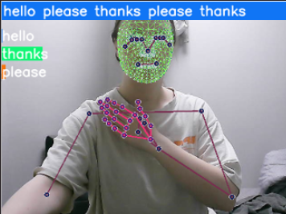

```python
colors = [(245,117,16), (117,245,16), (16,117,245), (255,0,0), (0,255,0), (0,0,255)]

def prob_viz(res, actions, input_frame, colors):
    output_frame = input_frame.copy()
    for num, prob in enumerate(res):
        cv2.rectangle(output_frame, (0, 60 + num * 40), (int(prob * 100), 90 + num * 40), colors[num], -1)
        cv2.putText(output_frame, actions[num], (0, 85 + num * 40), cv2.FONT_HERSHEY_SIMPLEX, 1, (255,255,255), 2, cv2.LINE_AA)

    return output_frame
```

```python
# 1. New detection variables
sequence = []
sentence = []
threshold = 0.8

cap = cv2.VideoCapture(1)
# Set mediapipe model
with mp_holistic.Holistic(min_detection_confidence=0.5, min_tracking_confidence=0.5) as holistic:
    while cap.isOpened():

        # Read feed
        ret, frame = cap.read()

        # Make detections
        image, results = mediapipe_detection(frame, holistic)
        print(results)

        # Draw landmarks
        draw_styled_landmarks(image, results)

        # 2. Prediction logic
        keypoints = extract_keypoints(results)
#         sequence.insert(0,keypoints)
#         sequence = sequence[:30]
        sequence.append(keypoints)
        sequence = sequence[-30:]

        if len(sequence) == 30:
            res = model.predict(np.expand_dims(sequence, axis=0))[0]
            print(actions[np.argmax(res)])


        #3. Viz logic
            if res[np.argmax(res)] > threshold:
                if len(sentence) > 0:
                    if actions[np.argmax(res)] != sentence[-1]:
                        sentence.append(actions[np.argmax(res)])
                else:
                    sentence.append(actions[np.argmax(res)])

            if len(sentence) > 5:
                sentence = sentence[-5:]

            # Viz probabilities
            image = prob_viz(res, actions, image, colors)

        cv2.rectangle(image, (0,0), (640, 40), (245, 117, 16), -1)
        cv2.putText(image, ' '.join(sentence), (3,30),
                       cv2.FONT_HERSHEY_SIMPLEX, 1, (255, 255, 255), 2, cv2.LINE_AA)

        # Show to screen
        cv2.imshow('OpenCV Feed', image)

        # Break gracefully
        if cv2.waitKey(10) & 0xFF == ord('q'):
            break
    cap.release()
    cv2.destroyAllWindows()
```

[output not shown]

[output not shown]

[output cut: 2058 more lines]

```
<class 'mediapipe.python.solution_base.SolutionOutputs'>
1/1 ━━━━━━━━━━━━━━━━━━━━ 0s 59ms/step
yes
<class 'mediapipe.python.solution_base.SolutionOutputs'>
1/1 ━━━━━━━━━━━━━━━━━━━━ 0s 62ms/step
yes
<class 'mediapipe.python.solution_base.SolutionOutputs'>
1/1 ━━━━━━━━━━━━━━━━━━━━ 0s 39ms/step
yes
<class 'mediapipe.python.solution_base.SolutionOutputs'>
1/1 ━━━━━━━━━━━━━━━━━━━━ 0s 40ms/step
yes
<class 'mediapipe.python.solution_base.SolutionOutputs'>
1/1 ━━━━━━━━━━━━━━━━━━━━ 0s 40ms/step
yes
```